# Soluções: Atividade Prática 4

Econometria Aplicada à Finanças  
Mestrado Profissional em Administração

Autor

Prof. Dr. Washington S. da Silva

Data de Publicação

1 de setembro de 2026

## Questão 1: Testando a presença de heterocedasticidade

**a.** Estime o modelo do item **l** da Atividade Prática 2 e construa o gráfico dos resíduos contra `pct_smoke`. O gráfico sugere heterocedasticidade?

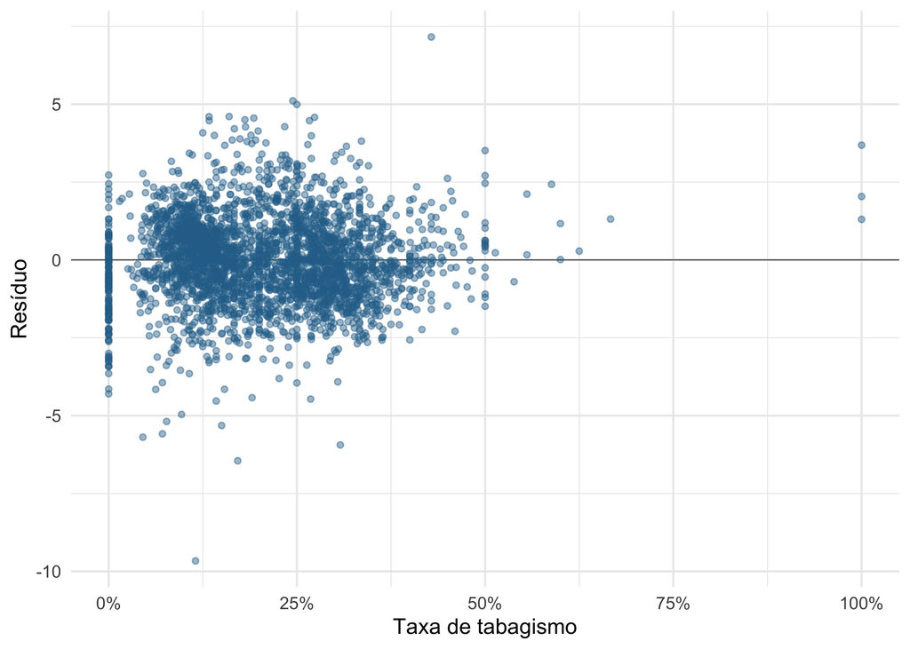

Resíduos do modelo contra a taxa de tabagismo.

```r
# Estima o modelo do item l da Atividade Prática 2
modelo_l <- lm(
  life_exp ~ pct_smoke + high_income + is_urban,
  data = life_df
)

# Acrescenta os resíduos do modelo aos dados
life_df <- life_df |>
  dplyr::mutate(residuo_l = residuals(modelo_l))

# Constrói o gráfico dos resíduos contra a taxa de tabagismo
ggplot2::ggplot(
  life_df,
  ggplot2::aes(x = pct_smoke, y = residuo_l)
) +
  ggplot2::geom_hline(
    yintercept = 0,
    linewidth = 0.3,
    color = "gray35"
  ) +
  ggplot2::geom_point(
    alpha = 0.45,
    size = 1.3,
    color = "#2A6F97"
  ) +
  ggplot2::scale_x_continuous(
    "Taxa de tabagismo",
    labels = scales::label_percent()
  ) +
  ggplot2::scale_y_continuous("Resíduo") +
  ggplot2::theme_minimal(base_size = 12)
```

**DicaResposta**

O gráfico não sugere fortemente heterocedasticidade, mas ela pode estar presente: níveis mais elevados de `pct_smoke` parecem apresentar menor variação dos resíduos.

**b.** Mantida a exogeneidade, quais são as consequências da heterocedasticidade para os coeficientes, os erros-padrão usuais e a eficiência do MQO?

**DicaResposta**

A heterocedasticidade, por si só, não torna os estimadores dos coeficientes de MQO viesados quando a exogeneidade é mantida. Entretanto, os erros-padrão usuais deixam de estimar corretamente a variabilidade dos estimadores, de modo que testes de hipóteses e intervalos de confiança usuais podem ser enganosos. Além disso, o MQO deixa de ser o estimador linear não viesado mais eficiente.

**c.** Realize o teste de Goldfeld–Quandt e interprete suas hipóteses, estatística, valor-*p* e decisão.

```r
# Executa o teste de Goldfeld–Quandt ordenado pela taxa de tabagismo
resultado_gq <- lmtest::gqtest(
  life_exp ~ pct_smoke + high_income + is_urban,
  data = life_df,
  order.by = ~ pct_smoke,
  point = 0.5,
  fraction = 1/3,
  alternative = "two.sided"
)

# Exibe o resultado do teste
resultado_gq
```

```
    Goldfeld-Quandt test

data:  life_exp ~ pct_smoke + high_income + is_urban
GQ = 0.866, df1 = 1032, df2 = 1031, p-value = 0.021
alternative hypothesis: variance changes from segment 1 to 2
```

**DicaResposta**

A hipótese nula afirma que a variância dos erros é igual nos terços inferior e superior da amostra ordenada por `pct_smoke`. A hipótese alternativa bicaudal afirma que as variâncias diferem. A estatística é 0.866 e o valor-*p* é 0.0206. Ao nível de 5%, rejeitamos a hipótese nula de igualdade das variâncias dos erros entre os dois grupos. O teste fornece evidências de heterocedasticidade.

**d.** Realize o teste de White e interprete suas hipóteses, estatística, valor-*p* e decisão.

```r
# Executa o teste de White a partir do modelo estimado
resultado_white <- whitestrap::white_test(modelo_l)

# Exibe o resultado do teste
resultado_white
```

```
White's test results

Null hypothesis: Homoskedasticity of the residuals
Alternative hypothesis: Heteroskedasticity of the residuals
Test Statistic: 39.96
P-value: 0
```

**DicaResposta**

A hipótese nula é de homocedasticidade dos resíduos; a alternativa é de heterocedasticidade. A estatística do teste é 39.96 e o valor-*p* é aproximadamente 2.10e-09. Rejeitamos a hipótese nula ao nível de 5%, encontrando evidências de heterocedasticidade.

**e.** Os testes de Goldfeld–Quandt e de White precisam concordar? O que ocorreu nesta aplicação?

**DicaResposta**

Não. O teste de Goldfeld–Quandt compara a variância residual entre dois grupos definidos após ordenar a amostra por uma variável. O teste de White procura uma relação mais flexível entre os resíduos ao quadrado e os valores ajustados do modelo. Como investigam formas diferentes de afastamento da homocedasticidade, podem produzir conclusões distintas. Nesta aplicação, ambos rejeitam a hipótese nula de homocedasticidade.

## Questão 2: Convivendo com a heterocedasticidade

**a.** Estime o modelo com interação entre `pct_smoke` e `high_income`, apresente os resultados e interprete o termo de interação.

```r
# Estima o modelo com interação entre tabagismo e alta renda
modelo_interacao <- lm(
  life_exp ~ pct_smoke * high_income + is_urban,
  data = life_df
)

# Apresenta os coeficientes e a inferência usual
knitr::kable(
  coef(summary(modelo_interacao)),
  digits = 3,
  caption = "Modelo com interação e erros-padrão usuais."
)
```

Modelo com interação e erros-padrão usuais.

|  | Estimate | Std. Error | t value | Pr(>\|t\|) |
| --- | --- | --- | --- | --- |
| (Intercept) | 80.544 | 0.138 | 584.830 | 0.000 |
| pct_smoke | -6.069 | 0.434 | -13.999 | 0.000 |
| high_income | 5.815 | 0.143 | 40.700 | 0.000 |
| is_urban | 0.033 | 0.061 | 0.534 | 0.593 |
| pct_smoke:high_income | 2.908 | 0.616 | 4.722 | 0.000 |

**DicaResposta**

O grupo de referência é o quartil de renda mais baixa (`high_income = 0`), e o grupo comparado é o quartil de renda mais alta (`high_income = 1`). O coeficiente da interação é 2.908. Assim, a inclinação da relação entre tabagismo e expectativa de vida é 2.908 anos maior — ou menos negativa — no grupo de renda mais alta do que no grupo de renda mais baixa.

**b.** No modelo com interação, a inclinação da relação estimada entre tabagismo e expectativa de vida depende do grupo de renda.

Para identificá-la, considere separadamente:

1. o grupo de renda mais baixa, para o qual `high_income = 0`;
2. o grupo de renda mais alta, para o qual `high_income = 1`.

Substitua esses valores na equação do item **a.** e reúna os termos que multiplicam a taxa de tabagismo. Verifique que a inclinação é:

- $\beta_1$ para o grupo de renda mais baixa;
- $\beta_1 + \beta_4$ para o grupo de renda mais alta.

Em seguida, use os coeficientes estimados para calcular as duas inclinações e interprete cada uma considerando um aumento de dez pontos percentuais na taxa de tabagismo. Como `pct_smoke` está expressa como proporção, multiplique cada inclinação estimada por $0,10$.

Interprete os resultados como associações estimadas, não como efeitos causais.

```r
# Calcula as inclinações implícitas por grupo de renda
inclinacao_baixa <- coef(modelo_interacao)["pct_smoke"]
inclinacao_alta <-
  coef(modelo_interacao)["pct_smoke"] +
  coef(modelo_interacao)["pct_smoke:high_income"]

# Organiza as inclinações e as variações associadas a dez pontos percentuais
inclinacoes <- data.frame(
  grupo = c("Renda mais baixa", "Renda mais alta"),
  inclinacao = c(inclinacao_baixa, inclinacao_alta),
  variacao_10pp = 0.10 * c(inclinacao_baixa, inclinacao_alta)
)

knitr::kable(inclinacoes, digits = 3)
```

| grupo | inclinacao | variacao_10pp |
| --- | --- | --- |
| Renda mais baixa | -6.069 | -0.607 |
| Renda mais alta | -3.161 | -0.316 |

**DicaResposta**

No grupo de renda mais baixa, `high_income = 0`. Portanto, a inclinação associada a `pct_smoke` é apenas o coeficiente de `pct_smoke`, estimado em -6.069.

No grupo de renda mais alta, `high_income = 1`. Nesse caso, a inclinação é a soma dos coeficientes de `pct_smoke` e da interação `pct_smoke:high_income`, resultando em -3.161.

Como `pct_smoke` está expressa como proporção, dez pontos percentuais correspondem a uma variação de 0,10. Assim, um aumento de dez pontos percentuais no tabagismo está associado a:

- uma variação estimada de -0.607 ano na expectativa de vida no grupo de renda mais baixa;
- uma variação estimada de -0.316 ano no grupo de renda mais alta.

A associação estimada é negativa nos dois grupos, mas menos negativa entre os condados de renda mais alta.

**c.** Calcule erros-padrão HC3 e compare a inferência sobre o termo de interação com a inferência usual.

```r
# Estima a matriz de covariância com a correção HC3
vcov_hc3 <- sandwich::vcovHC(modelo_interacao, type = "HC3")

# Calcula a inferência com a matriz HC3
resultado_hc3 <- lmtest::coeftest(modelo_interacao, vcov. = vcov_hc3)

# Compara a inferência usual e HC3 para o termo de interação
comparacao_interacao <- data.frame(
  inferencia = c("Usual", "HC3"),
  coeficiente = c(
    coef(modelo_interacao)["pct_smoke:high_income"],
    resultado_hc3["pct_smoke:high_income", "Estimate"]
  ),
  erro_padrao = c(
    coef(summary(modelo_interacao))["pct_smoke:high_income", "Std. Error"],
    resultado_hc3["pct_smoke:high_income", "Std. Error"]
  ),
  valor_p = c(
    coef(summary(modelo_interacao))["pct_smoke:high_income", "Pr(>|t|)"],
    resultado_hc3["pct_smoke:high_income", "Pr(>|t|)"]
  )
)

knitr::kable(comparacao_interacao, digits = 6)
```

|  | inferencia | coeficiente | erro_padrao | valor_p |
| --- | --- | --- | --- | --- |
| pct_smoke:high_income | Usual | 2.9078 | 0.61579 | 0.000002 |
|  | HC3 | 2.9078 | 0.76082 | 0.000135 |

**DicaResposta**

O erro-padrão usual do termo de interação é 0.616, enquanto o HC3 é 0.761. O valor-*p* passa de aproximadamente 2.44e-06 para 1.35e-04. A incerteza estimada aumenta, mas o termo de interação permanece estatisticamente significativo ao nível de 5%. Apenas a matriz de covariância foi substituída; os coeficientes não foram reestimados.

**d.** Estime o modelo por MQP com `weights = pop`, calcule HC3 para os dois modelos e compare os resultados.

```r
# Estima o modelo ponderado pela população do condado
modelo_mqp <- lm(
  life_exp ~ pct_smoke * high_income + is_urban,
  data = life_df,
  weights = pop
)

# Estima a matriz HC3 para o modelo ponderado
vcov_mqp_hc3 <- sandwich::vcovHC(modelo_mqp, type = "HC3")

# Calcula a inferência HC3 para o modelo ponderado
resultado_mqp_hc3 <- lmtest::coeftest(
  modelo_mqp,
  vcov. = vcov_mqp_hc3
)

# Reúne os modelos em uma lista nomeada
modelos_mqo_mqp <- list(
  "MQO não ponderado — HC3" = modelo_interacao,
  "MQP ponderado por população — HC3" = modelo_mqp
)

# Reúne as matrizes HC3 na mesma ordem dos modelos
matrizes_hc3 <- list(
  vcov_hc3,
  vcov_mqp_hc3
)

# Apresenta os resultados dos modelos lado a lado
modelsummary::modelsummary(
  models = modelos_mqo_mqp,
  vcov = matrizes_hc3,
  statistic = "({std.error})",
  stars = TRUE,
  fmt = 3,
  gof_map = c("nobs", "r.squared", "adj.r.squared")
)
```

|  | MQO não ponderado — HC3 | MQP ponderado por população — HC3 |
| --- | --- | --- |
| (Intercept) | 80.544*** | 84.786*** |
|  | (0.170) | (0.649) |
| pct_smoke | -6.069*** | -20.699*** |
|  | (0.519) | (2.180) |
| high_income | 5.815*** | 2.142** |
|  | (0.176) | (0.667) |
| is_urban | 0.033 | 0.278*** |
|  | (0.068) | (0.083) |
| pct_smoke × high_income | 2.908*** | 13.400*** |
|  | (0.761) | (2.295) |
| Num.Obs. | 3106 | 3106 |
| R2 | 0.874 | 0.887 |
| R2 Adj. | 0.874 | 0.886 |

+ p < 0.1, * p < 0.05, ** p < 0.01, *** p < 0.001

**DicaResposta**

A ponderação altera substancialmente as estimativas. Por exemplo, o coeficiente de `pct_smoke` muda de -6.069 para -20.699, e o coeficiente da interação muda de 2.908 para 13.4. Isso ocorre porque os condados mais populosos recebem maior influência; o modelo ponderado descreve uma relação ponderada pela população, enquanto o modelo não ponderado atribui o mesmo peso a cada observação condado–grupo de renda.

Ponderar por `pop` não resolve automaticamente a heterocedasticidade. Para obter o ganho de eficiência associado ao MQP, os pesos deveriam ser proporcionais ao inverso da variância condicional dos erros. A população pode não representar essa relação e também não deve ser interpretada automaticamente como o tamanho exato de cada célula condado–quartil. Por isso, usamos HC3 nos dois modelos.

## Questão 3: Erros-padrão robustos a agrupamentos

**a.** Por que erros correlacionados podem ser uma preocupação neste conjunto de dados?

**DicaResposta**

Erros correlacionados ocorrem quando determinantes não observados da expectativa de vida estão relacionados entre diferentes observações. A base contém observações repetidas por condado: uma para o quartil de renda mais baixo e outra para o mais alto. Se um fator não observado no nível do condado afetar a expectativa de vida dos dois grupos, os erros dessas observações poderão estar correlacionados.

**b.** Estime o modelo com erros-padrão robustos a agrupamentos e agrupamento por condado.

```r
# Estima o modelo com erros-padrão robustos a agrupamentos por condado
modelo_condado <- fixest::feols(
  life_exp ~ pct_smoke * high_income + is_urban,
  data = life_df,
  vcov = ~ county_code
)

# Apresenta os resultados com agrupamento por condado
knitr::kable(
  fixest::coeftable(modelo_condado),
  digits = 3,
  caption = "Modelo com agrupamento por condado."
)
```

Modelo com agrupamento por condado.

|  | Estimate | Std. Error | t value | Pr(>\|t\|) |
| --- | --- | --- | --- | --- |
| (Intercept) | 80.544 | 0.170 | 474.390 | 0.000 |
| pct_smoke | -6.069 | 0.513 | -11.825 | 0.000 |
| high_income | 5.815 | 0.165 | 35.249 | 0.000 |
| is_urban | 0.033 | 0.076 | 0.427 | 0.669 |
| pct_smoke:high_income | 2.908 | 0.713 | 4.080 | 0.000 |

**DicaResposta**

Os resultados são apresentados na tabela acima.

**c.** Compare o agrupamento por condado com HC3 e avalie se as conclusões mudam.

```r
# Reúne os erros-padrão HC3 e agrupados por condado
comparacao_condado <- data.frame(
  termo = rownames(resultado_hc3),
  erro_padrao_hc3 = resultado_hc3[, "Std. Error"],
  erro_padrao_condado = fixest::coeftable(modelo_condado)[, "Std. Error"]
)

knitr::kable(comparacao_condado, digits = 3)
```

|  | termo | erro_padrao_hc3 | erro_padrao_condado |
| --- | --- | --- | --- |
| (Intercept) | (Intercept) | 0.170 | 0.170 |
| pct_smoke | pct_smoke | 0.519 | 0.513 |
| high_income | high_income | 0.176 | 0.165 |
| is_urban | is_urban | 0.068 | 0.076 |
| pct_smoke:high_income | pct_smoke:high_income | 0.761 | 0.713 |

**DicaResposta**

HC3 permite heterocedasticidade, mas trata as observações como independentes. O agrupamento por condado também permite que os erros das duas observações do mesmo condado estejam correlacionados. Os erros-padrão são semelhantes nesta aplicação. Para a interação, eles são 0.761 com HC3 e 0.713 com agrupamento por condado. O tabagismo, a alta renda e a interação permanecem estatisticamente significativos. Portanto, as principais conclusões não mudam.

**d.** Estime o modelo com agrupamento por estado e compare HC3, agrupamento por condado e agrupamento por estado.

```r
# Estima o modelo com erros-padrão robustos a agrupamentos por estado
modelo_estado <- fixest::feols(
  life_exp ~ pct_smoke * high_income + is_urban,
  data = life_df,
  vcov = ~ state_abb
)

# Compara os erros-padrão das três matrizes de covariância
comparacao_agrupamentos <- data.frame(
  termo = rownames(resultado_hc3),
  erro_padrao_hc3 = resultado_hc3[, "Std. Error"],
  erro_padrao_condado = fixest::coeftable(modelo_condado)[, "Std. Error"],
  erro_padrao_estado = fixest::coeftable(modelo_estado)[, "Std. Error"]
)

knitr::kable(comparacao_agrupamentos, digits = 3)
```

|  | termo | erro_padrao_hc3 | erro_padrao_condado | erro_padrao_estado |
| --- | --- | --- | --- | --- |
| (Intercept) | (Intercept) | 0.170 | 0.170 | 0.399 |
| pct_smoke | pct_smoke | 0.519 | 0.513 | 1.108 |
| high_income | high_income | 0.176 | 0.165 | 0.386 |
| is_urban | is_urban | 0.068 | 0.076 | 0.107 |
| pct_smoke:high_income | pct_smoke:high_income | 0.761 | 0.713 | 1.278 |

**DicaResposta**

Nesta aplicação, o erro-padrão estadual da interação é 1.278, maior que o erro-padrão de 0.713 obtido por condado. O valor-*p* estadual da interação é 0.0274; a interação permanece significativa a 5%, mas a evidência é mais fraca.

Um agrupamento mais abrangente não precisa gerar erros-padrão maiores para todos os coeficientes. O resultado depende da covariância empírica dos escores dentro dos grupos, inclusive de seus sinais, e dos ajustes de amostra finita, não apenas do tamanho geográfico do agrupamento.

**e.** Sintetize o que os resultados sugerem sobre tabagismo e expectativa de vida, considerando viés de variável omitida, heterocedasticidade, agrupamento e causalidade.

**DicaResposta**

Taxas de tabagismo mais elevadas estão associadas a menor expectativa de vida, mas a relação bivariada simples é enganosa porque o grupo de renda está relacionado às duas variáveis; como visto na Atividade Prática 2, controlar para alta renda torna o coeficiente do tabagismo menos negativo, de forma consistente com viés de variável omitida para baixo no modelo simples. O gráfico e os testes formais indicam heterocedasticidade, de modo que os erros-padrão usuais não são apropriados. Como há observações repetidas por condado e possível dependência geográfica mais ampla, erros-padrão robustos a agrupamentos também são pertinentes. Erros-padrão numericamente pequenos não garantem inferência confiável se a matriz de covariância foi estimada sob hipóteses inadequadas. Por fim, essas regressões descrevem associações condicionais e não identificam um efeito causal do tabagismo sobre a expectativa de vida.